# Titanic Disaster Prediction 2022

Salisu Mohammed

Created on November 22, 2022, Updated on January 09, 2023

# Predicting Survivability Using RandomForest - First Kaggle Entry

We begin by loading the necessary packages

```r
library(readr)
library(dplyr)
library(ggplot2)
```

## The Train data and Test Data

The train and test data are available on y local computer, I have also included them in the folder of this directory should you need them.

```r
# import the train data

train <- read_csv("train.csv")

# import the test data
test <- read_csv("test.csv")
```

We will use the `train` data on randomforest and then run the prediction on the `test` data.

```r
head(train)

# examine the structure

glimpse(train)
```

Add a new Survived column to the `test` data. You can do this in different ways, but I choose to use mutate in this case.

[output not shown]

Bind the `train` and `test.survived` datasets

```r
train.test <- rbind(train, test.survived)

head(train.test)
```

### Converting columns to the appropriate class.

```r
# Convert Sex, Pclass, Sex, Survived, SibSp, Parch, Embrked to factors

# check the structure

# create a function to convert variable class

convert_func <- function(x) {
  x <- as.factor(x)
}

glimpse(train.test)
```

```
Rows: 1,309
Columns: 12
$ PassengerId <dbl> 1, 2, 3, 4, 5, 6, 7, 8, 9, 10, 11, 12, 13, 14, 15, …
$ Survived    <chr> "0", "1", "1", "1", "0", "0", "0", "0", "1", "1", "…
$ Pclass      <dbl> 3, 1, 3, 1, 3, 3, 1, 3, 3, 2, 3, 1, 3, 3, 3, 2, 3, …
$ Name        <chr> "Braund, Mr. Owen Harris", "Cumings, Mrs. John Brad…
$ Sex         <chr> "male", "female", "female", "female", "male", "male…
$ Age         <dbl> 22, 38, 26, 35, 35, NA, 54, 2, 27, 14, 4, 58, 20, 3…
$ SibSp       <dbl> 1, 1, 0, 1, 0, 0, 0, 3, 0, 1, 1, 0, 0, 1, 0, 0, 4, …
$ Parch       <dbl> 0, 0, 0, 0, 0, 0, 0, 1, 2, 0, 1, 0, 0, 5, 0, 0, 1, …
$ Ticket      <chr> "A/5 21171", "PC 17599", "STON/O2. 3101282", "11380…
$ Fare        <dbl> 7.2500, 71.2833, 7.9250, 53.1000, 8.0500, 8.4583, 5…
$ Cabin       <chr> NA, "C85", NA, "C123", NA, NA, "E46", NA, NA, NA, "…
$ Embarked    <chr> "S", "C", "S", "S", "S", "Q", "S", "S", "S", "C", "…
```

```r
train.test <- train.test %>%
  mutate(
    Pclass = convert_func(Pclass),
    Sex = convert_func(Sex),
    Survived = convert_func(Survived),
    Parch = convert_func(Parch),
    SibSp = convert_func(SibSp),
    Embarked = convert_func(Embarked)
  )

glimpse(train.test)
```

```
Rows: 1,309
Columns: 12
$ PassengerId <dbl> 1, 2, 3, 4, 5, 6, 7, 8, 9, 10, 11, 12, 13, 14, 15, …
$ Survived    <fct> 0, 1, 1, 1, 0, 0, 0, 0, 1, 1, 1, 1, 0, 0, 0, 1, 0, …
$ Pclass      <fct> 3, 1, 3, 1, 3, 3, 1, 3, 3, 2, 3, 1, 3, 3, 3, 2, 3, …
$ Name        <chr> "Braund, Mr. Owen Harris", "Cumings, Mrs. John Brad…
$ Sex         <fct> male, female, female, female, male, male, male, mal…
$ Age         <dbl> 22, 38, 26, 35, 35, NA, 54, 2, 27, 14, 4, 58, 20, 3…
$ SibSp       <fct> 1, 1, 0, 1, 0, 0, 0, 3, 0, 1, 1, 0, 0, 1, 0, 0, 4, …
$ Parch       <fct> 0, 0, 0, 0, 0, 0, 0, 1, 2, 0, 1, 0, 0, 5, 0, 0, 1, …
$ Ticket      <chr> "A/5 21171", "PC 17599", "STON/O2. 3101282", "11380…
$ Fare        <dbl> 7.2500, 71.2833, 7.9250, 53.1000, 8.0500, 8.4583, 5…
$ Cabin       <chr> NA, "C85", NA, "C123", NA, NA, "E46", NA, NA, NA, "…
$ Embarked    <fct> S, C, S, S, S, Q, S, S, S, C, S, S, S, S, S, S, Q, …
```

## Exploratory Data Analysis

Let’s see the total number of people that survived or perish from the `train.test` data.

```r
train.test %>%
  count(Survived)
```

| Survived | n |
| --- | --- |
| 0 | 549 |
| 1 | 342 |
| none | 418 |

They are 549 victims and 342 survivor from the `train` data. the “none” paramenter is from the newly created survived column in the `test` data.

Let’s explore the data some more

```r
train.test %>%
  count(Pclass)
```

| Pclass | n |
| --- | --- |
| 1 | 323 |
| 2 | 277 |
| 3 | 709 |

```r
summary(train.test$Sex)
```

```
female   male
   466    843
```

```r
summary(train.test$SibSp)
```

```
  0   1   2   3   4   5   8
891 319  42  20  22   6   9
```

```r
summary(train.test$Parch)
```

```
   0    1    2    3    4    5    6    9
1002  170  113    8    6    6    2    2
```

```r
summary(train.test$Age)
```

```
   Min. 1st Qu.  Median    Mean 3rd Qu.    Max.    NA's
   0.17   21.00   28.00   29.88   39.00   80.00     263
```

### Visualising the predictive behavior of each variable

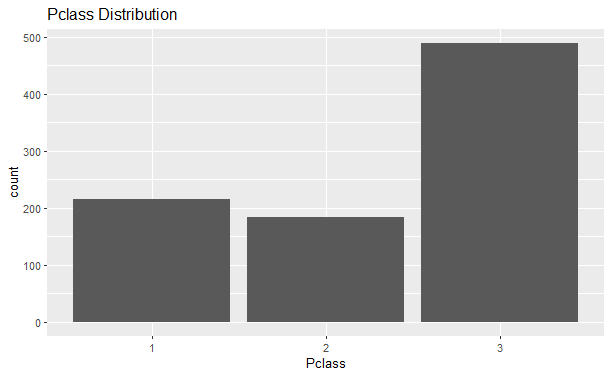

```r
ggplot(train.test[1:890, ], aes(Pclass)) +
  geom_bar() +
  ggtitle("Pclass Distribution")
```

There are more passengers in third class than any other class which makes sense given the social class of that category.

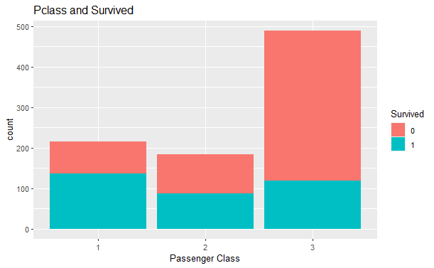

```r
ggplot(train.test[1:890, ], aes(Pclass, fill = factor(Survived))) +
  geom_bar() +
  xlab("Passenger Class") +
  labs(fill = "Survived") +
  ggtitle("Pclass and Survived")
```

Third class has the highest number of casualties. This might be because of the location of the third class cabin, which makes it harder to come to the top. Most of the people down there are either trapped or drown before getting help.

In situations like these, women and children are given more preference. A visual of the age distribution to explore more age related prediction.

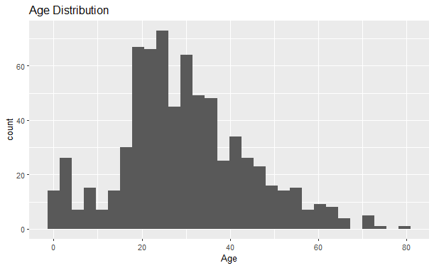

```r
ggplot(train.test[1:890, ], aes(Age))+
  geom_histogram() +
  ggtitle("Age Distribution")
```

The Age distribution is more clusterd around 20-40 years. According to the data, children are more than likely to survive than adult. We will visualise this hypothesis next but only for exploration.

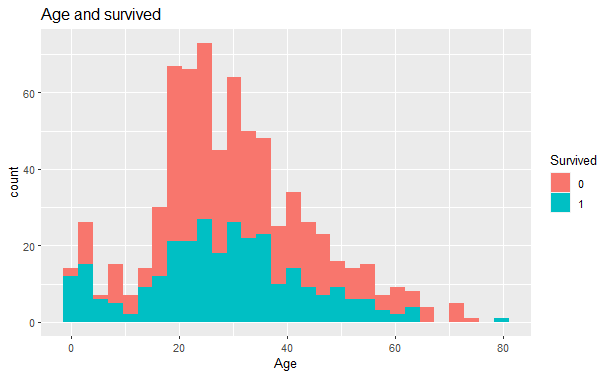

```r
ggplot(train.test[1:891, ], aes(Age, fill = Survived)) +
  geom_histogram() +
  ggtitle("Age and survived")
```

Aha! Age is a good predictor. In addition to age, we want to look at the distribution of sex and whether it is also a good predictor. Are females more likely to survive than males? Knowing the answer to question such as this will help us prevent our prediction from model bias.

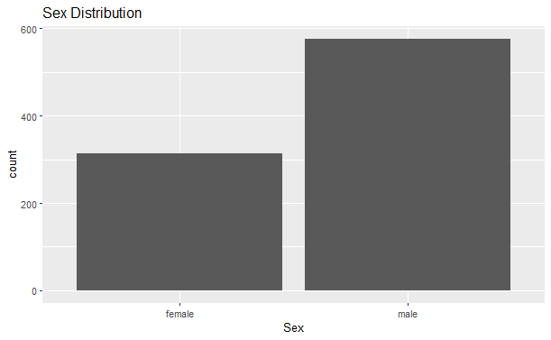

```r
ggplot(train.test[1:891, ], aes(Sex)) +
  geom_bar() +
  ggtitle("Sex Distribution")
```

More males onboard than female.

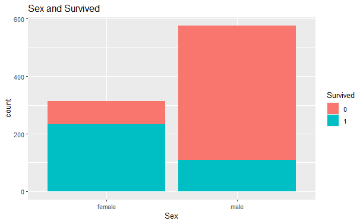

```r
ggplot(train.test[1:891, ], aes(Sex, fill = Survived)) +
  geom_bar() +
  ggtitle("Sex and Survived")
```

Oops! A large chunk of males onboard perished.

##### Multi-variate exploration

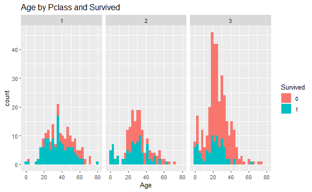

```r
ggplot(train.test[1:891, ], aes(Age, fill = Survived)) +
  geom_histogram() +
  facet_wrap(~ Pclass) +
  ggtitle("Age by Pclass and Survived")
```

##### The SibSp and Parch Variable

SipSp is the number of siblings or spouses traveling together. Parch shows whether a passenger is travelling with a parent or partner.

**Question: Does a passenger travelling alone has a higher chance of survival?**

To answer this, we will be looking at the distribution of each variable.

We will later transfrom this to a new variable later.

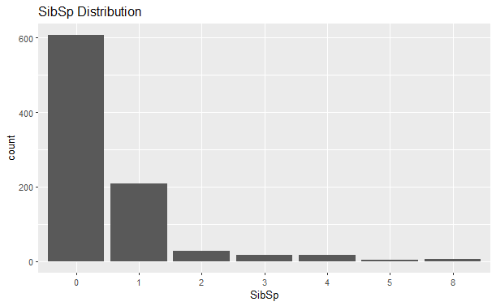

```r
ggplot(train.test[1:891, ], aes(SibSp)) +
  geom_bar() +
  ggtitle("SibSp Distribution")
```

Let’s add the survival rate

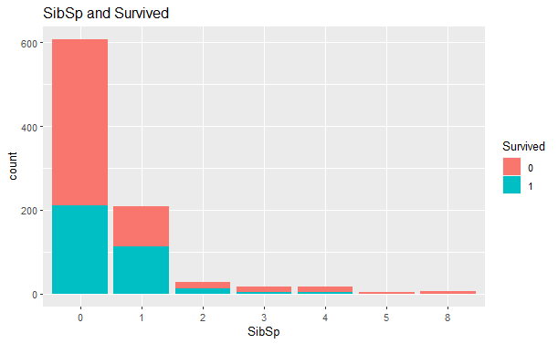

```r
ggplot(train.test[1:891, ], aes(SibSp, fill = Survived)) +
  geom_bar() +
  ggtitle("SibSp and Survived")
```

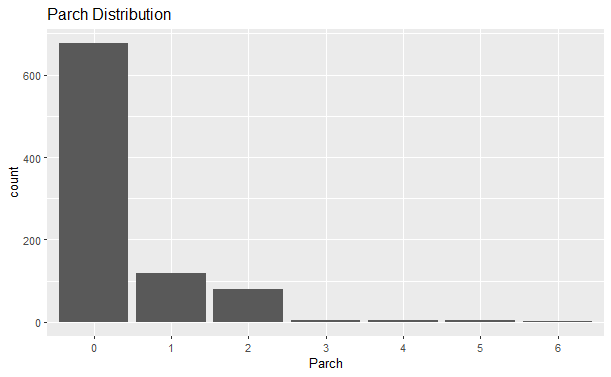

```r
ggplot(train.test[1:891, ], aes(Parch)) +
  geom_bar() +
  ggtitle("Parch Distribution")
```

Hmm! looks like the same pattern. next…

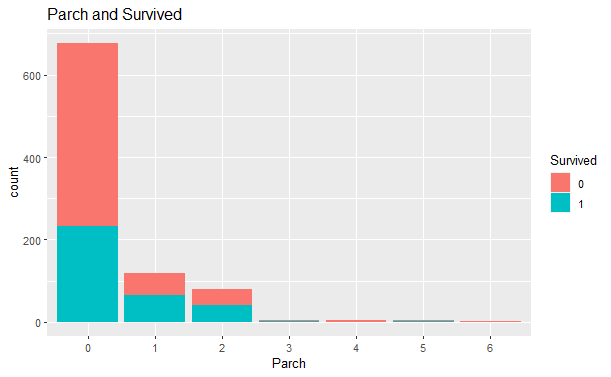

```r
ggplot(train.test[1:891, ], aes(Parch, fill = Survived)) +
  geom_bar() +
  ggtitle("Parch and Survived")
```

## Feature Engineering

### Adult Child Age Group

Creating a Child and Adult Variable from the `train.test` data.

```r
# create a childadult_function

chAdult_func <- function(x) {
  case_when(
    x <= 13 ~ "Child",
    x>= 13 & x <= 19 ~ "Teenager", TRUE ~ "Adult"
  )
}

Adult_Child <- NULL #create a null file

for (i in 1:nrow(train.test)) {
  Adult_Child <- c(Adult_Child, chAdult_func(train.test[i, "Age"]))
}

# create a new column and add the Adult_Child vector

train.test <- train.test %>%
  mutate(Age_group = Adult_Child)

# call summary on the new variable

table(train.test$Age_group)
```

```
   Adult    Child Teenager
    1084       99      126
```

Visualise the distribution across Pclass

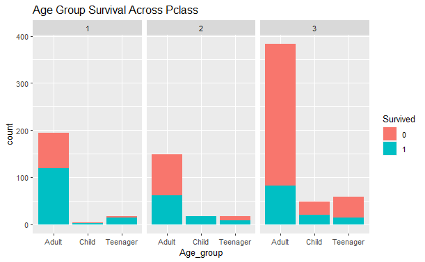

```r
ggplot(train.test[1:891, ], aes(Age_group, fill = Survived)) +
  geom_bar() +
  facet_wrap(~ Pclass) +
  ggtitle("Age Group Survival Across Pclass")
```

Wow! this shows us more prediction than the age.

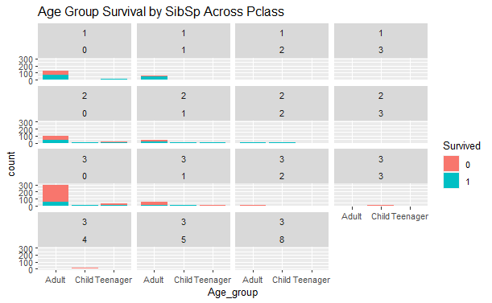

```r
ggplot(train.test[1:891, ], aes(Age_group, fill = Survived)) +
  geom_bar() +
  facet_wrap(~ Pclass ~ SibSp) +
  ggtitle("Age Group Survival by SibSp Across Pclass")
```

Ouch! the pattern seems to be hard to read. Since both SIbSp and Parch shows the number of dependent/spouse/siblings/parents/guardians traveling together, we will use this information to create a new **Family_Size** variable.

```r
# create a vector of the sibsp and parch variable and add them together

train.temp <- c(train$SibSp, test$SibSp)
test.temp <- c(test$Parch, train$Parch)

train.test <- train.test %>%
  mutate(Family_size = as.factor(train.temp + test.temp + 1))
```

Relationship between Age group, Family Size and Survival rate

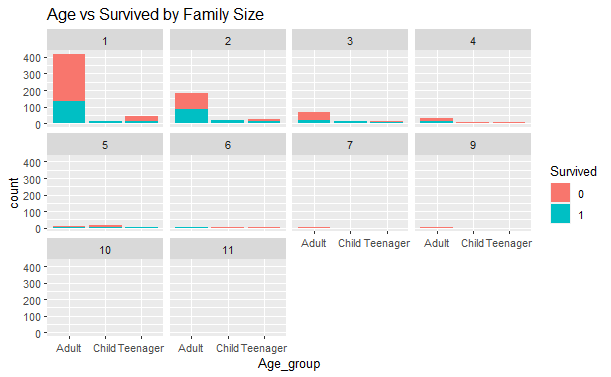

```r
ggplot(train.test[1:891, ], aes(Age_group, fill = Survived)) +
  geom_bar() +
  facet_wrap(~ Family_size) +
  ggtitle("Age vs Survived by Family Size")
```

## Training the RandomForest Algorithm

Now that we have looked at the varibles with the most predictive nature, we will be training our `RandomForest` algorithm with them.

```r
library(randomForest)
```

[figure not shown]

### Running Our Model on the Test Data

```r
table(prediction)
```

```
prediction
  0   1
270 148
```

Thank you for reading. please leave me a comment. I am currently looking for collaboration on real world projects to add to my portfolio. email me write.ethereal@gmail.com